# R Learner’s Permit Exam - Answers

Wonjin Jeong

2/18/2021

# Introduction

Over the course of the first few weeks of our class, you have learned some basic elements of the R programming language and RStudio IDE. As we move forward with our class, we will continue to add knowledge of new packages, tools, and data within R.

This R Learner’s Permit is designed to assess your knowledge of the core elements of the R language and software that we have focused on so far in class.

## Instructions

Please follow the instructions contained in this R Notebook, which involve filling in code and generating output. Most instructions ask you to add or fill in code chunks. Others ask you to provide a written interpretation in the notebook portion of the document.

Complete as many items as you can. If you run into trouble completing an item, add comments to your code or in the notebook describing where you are running into problems, and what you think the next step might be to solving the problem you’re having.

Complete as many items as you can and then upload your R Notebook to the “R Learners Permit” folder in your assignment repository on GitHub.

## The Data

In the “data” subfolder of this project, you will find one .rds file called NYC_Violations.rds. This is the data you will use to earn your learner’s permit. These are “real world” data derived from two sources:

1. New York City [housing maintainance code violation](https://data.cityofnewyork.us/Housing-Development/Housing-Maintenance-Code-Violations/wvxf-dwi5) data for the years 2009 to 2019
2. Data on property characteristics from the [Primary Land Use Tax Lot Output (PLUTO)](https://www1.nyc.gov/site/planning/data-maps/open-data/dwn-pluto-mappluto.page) database

I have merged selected columns from these datasets for you (you will find data documentation and metadata for both datasets in the documentation subfolder), and after taking a close look at the dataset and the documentation, you should be able to identify which portions of the data you will work with come from each dataset.

The PLUTO data contains information on each [tax lot](http://gis.nyc.gov/taxmap/map.htm) within the city of New York. By merging these data which contain characteristics of buildings and land with the building code violation data, the data you have to work with describes the characteristics of the building and property where the violation occurred as well as the nature of the violation. It is essential for you to spend the time to think carefully about what each row in the building code violation data represents.

# Earn Your Learner’s Permit

With that background in mind, its time to earn your learner’s permit.

## Task 1: Load and Describe the Data

At the beginning of the script, we will create a holding area within which you can load any packages you may need to work with as you year your R Learner’s Permit (if you are not using any packages, please leave this area blank):

[output not shown]

Use the `readRDS()` command to load the data into an object with the name of your choice.

```r
# Your Code Here
data <- readRDS("data/NYC_Violations_WB.rds")
```

Describe the structure of the data, including the number of rows and columns in the data. Create a table outside of the code chunk below in your notebook that describes each variable name and what each row in the data represents (a [Markdown table generator](https://www.tablesgenerator.com/markdown_tables) may be useful):

```r
dim(data)  #the number of rows in the first element, and the number of columns as the second element
```

```
[1] 4473752      12
```

```r
str(data)
```

```
tibble [4,473,752 x 12] (S3: tbl_df/tbl/data.frame)
 $ BBL            : chr [1:4473752] "3046740064" "2040040009" "2024820030" "3046050019" ...
 $ Borough        : chr [1:4473752] "BROOKLYN" "BRONX" "BRONX" "BROOKLYN" ...
 $ NTA            : chr [1:4473752] "East Flatbush-Farragut" "East Tremont" "West Concourse" "Prospect Lefferts Gardens-Wingate" ...
 $ ViolationStatus: chr [1:4473752] "Close" "Close" "Close" "Close" ...
 $ InspectionYear : num [1:4473752] 2013 2013 2013 2013 2013 ...
 $ unitstotal     : num [1:4473752] 4 3 93 6 6 6 4 3 3 6 ...
 $ ownername      : chr [1:4473752] "BAINBRIDGE BROOKLYN REALTY 364 LLC" "MORRISON, ROBERT" "PARKASH 751 LLC" "RUTLAND CORNERS, LLC" ...
 $ assessland     : num [1:4473752] 141300 7860 80550 7650 5400 ...
 $ assesstot      : num [1:4473752] 189000 40920 1714950 234000 112860 ...
 $ yearbuilt      : num [1:4473752] 1930 1899 1928 1930 1930 ...
 $ histdist       : chr [1:4473752] NA NA "Grand Concourse Historic District" NA ...
 $ OrderNumber    : num [1:4473752] 508 686 501 686 686 686 502 686 686 686 ...
```

```r
summary(data)
```

```
     BBL              Borough              NTA            ViolationStatus    InspectionYear   unitstotal
 Length:4473752     Length:4473752     Length:4473752     Length:4473752     Min.   :2009   Min.   :    0.00
 Class :character   Class :character   Class :character   Class :character   1st Qu.:2013   1st Qu.:    6.00
 Mode  :character   Mode  :character   Mode  :character   Mode  :character   Median :2016   Median :   23.00
                                                                             Mean   :2015   Mean   :   57.73
                                                                             3rd Qu.:2018   3rd Qu.:   54.00
                                                                             Max.   :2019   Max.   :17369.00
                                                                                            NA's   :17505
  ownername           assessland          assesstot           yearbuilt       histdist          OrderNumber
 Length:4473752     Min.   :        0   Min.   :        0   Min.   :   0    Length:4473752     Min.   :   4.0
 Class :character   1st Qu.:    17220   1st Qu.:   309150   1st Qu.:1914    Class :character   1st Qu.: 508.0
 Mode  :character   Median :    70200   Median :   712350   Median :1926    Mode  :character   Median : 556.0
                    Mean   :   278749   Mean   :  1920648   Mean   :1923                       Mean   : 654.6
                    3rd Qu.:   180000   3rd Qu.:  1454850   3rd Qu.:1931                       3rd Qu.: 702.0
                    Max.   :134506350   Max.   :789297750   Max.   :2019                       Max.   :1506.0
                    NA's   :17505       NA's   :17505       NA's   :17505
```

**Your Narrative Description of the Data Structure:**

The number of rows is 4,473,752, and The number of columns is 12, which indicates the data had 12 variables (n = 4,473,752). To examine each variable, str() function was used; The following six objects’ class was character: BBL (a unique identifier for each tax lot in the city), Borough (The borough where the building is located), NTA (Neighborhood Tabulation Area), ViolationStatus, ownername, and histdist. The following six obejects’ class was numeric: InspectionYear, unitstotal, assessland, assesstot, yearbuilt, and OrderNumber (reference to the abstract description of the violation condition). summary() function performed a series of calculations and produced descriptive statistics such as the minimum, the 1st qunatile, the median, the mean, the 3rd quantile, the maixmum value, and missing data of this dataset.

Reference: NYC Department of Housing Preservation and Development. (2019). Housing Maintenance Code Violations User Guide. https://data.cityofnewyork.us/Housing-Development/Housing-Maintenance-Code-Violations/wvxf-dwi5

## Task 2: Summarize Violations

Describe the number of unique violations for each year (information on the year the unit was inspected for violations is contained in the InspectionYear variable):

```r
data %>% group_by(InspectionYear) %>% summarise(Count = n())
```

| InspectionYear | Count |
| --- | --- |
| 2009 | 129891 |
| 2010 | 153951 |
| 2011 | 196874 |
| 2012 | 290909 |
| 2013 | 378807 |
| 2014 | 396618 |
| 2015 | 549297 |
| 2016 | 512530 |
| 2017 | 555997 |
| 2018 | 641750 |

[output cut: 1 more lines]

Now, build upon your summary code to make a plot (geometry of your choice) of inspections by year:

```r
options(scipen=999)
format(summary(data), big.mark = ",") #coding for full display number
```

[output not shown]

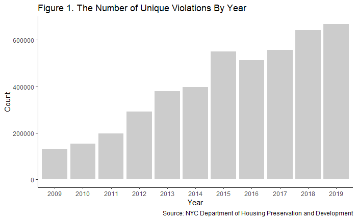

```r
data %>% group_by(InspectionYear) %>%
  ggplot(aes(x=as.factor(InspectionYear)))+
  geom_bar(fill = "gray80")+
  labs(title = "Figure 1. The Number of Unique Violations By Year", x="Year", y= "Count", caption = "Source: NYC Department of Housing Preservation and Development")+
  theme_classic()
```

In your own words, what is the overall trend with regards to the number of violations issued between 2009 and 2019?:

**Your Narrative Description:**

As shown in Figure 1, the number of unique violations has significantly increased from 129,891 in 2009 to 667,128 in 2019 (414% increase). There is a general tendency of increase in violations, except for 2015-2016, when the number of unique violations decreased by 36,767 from the prior year (a 6.7% drop).

Next, describe the number of unique violations for each New York City borough. Do this using both *base* r code and using `dplyr` code that utilizes the `summarise()` function:

```r
data %>% group_by(Borough) %>% summarise(Count = n())
```

| Borough | Count |
| --- | --- |
| BRONX | 1377887 |
| BROOKLYN | 1651373 |
| MANHATTAN | 902948 |
| QUEENS | 464672 |
| STATEN ISLAND | 76872 |

## Task 3: More Detail on Violations

Let’s create some more detailed summaries of violations.

Create a table that enumerates by borough the number of violations that are currently closed or open (ViolationStatus). Remove the `NA` values so that you are just reporting open and closed cases:

```r
data %>%
  filter(!is.na(ViolationStatus)) %>%
  group_by(Borough, ViolationStatus) %>% summarise(Count = n())
```

| Borough | ViolationStatus | Count |
| --- | --- | --- |
| BRONX | Close | 1100272 |
| BRONX | Open | 275978 |
| BROOKLYN | Close | 1118787 |
| BROOKLYN | Open | 530670 |
| MANHATTAN | Close | 682682 |
| MANHATTAN | Open | 219306 |
| QUEENS | Close | 271792 |
| QUEENS | Open | 192449 |
| STATEN ISLAND | Close | 40080 |
| STATEN ISLAND | Open | 36681 |

See if you can refine the formatting of this table. Although we haven’t formally introduced `pivot_wider()` yet, try using it so that you produce a summary in which there are three columns - the borough, the number of closed cases, and the number of open cases (remember you can search for documentation, e.g. `?pivot_wider()`). You will need to supply pivot_wider with an argument for `names_from` and an argument for `values_from`. Names should come from the Violation Status column, and values should come from the column in which the count of violations is contained.

```r
data %>%
  filter(!is.na(ViolationStatus)) %>%
  group_by(Borough, ViolationStatus) %>% summarise(Count = n()) %>%
  pivot_wider(names_from = ViolationStatus, values_from = Count)
```

| Borough | Close | Open |
| --- | --- | --- |
| BRONX | 1100272 | 275978 |
| BROOKLYN | 1118787 | 530670 |
| MANHATTAN | 682682 | 219306 |
| QUEENS | 271792 | 192449 |
| STATEN ISLAND | 40080 | 36681 |

```r
NA
```

Now create a chart (geom of your choice) that represents the number of *open cases* by borough by the year in which the violation occurred:

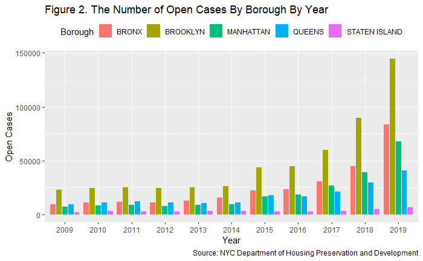

```r
open_year <- data %>%
  filter(!is.na(ViolationStatus)) %>%
  group_by(Borough, ViolationStatus, InspectionYear) %>% summarise(Count = n()) %>%
  pivot_wider(names_from = ViolationStatus, values_from = Count)
p <- ggplot(open_year, aes(x=as.factor(InspectionYear), y= Open, fill = Borough))
p + geom_col(position = "dodge2") + labs(title = "Figure 2. The Number of Open Cases By Borough By Year", x= "Year", y= "Open Cases", caption = "Source: NYC Department of Housing Preservation and Development") + theme(legend.position = "top")
```

Now, create a table with the total number of *buildings* with violations (remember, there may be multiple violations per building in the data). Remember that the BBL column contains a unique identification number for each building (technically it’s each tax lot, but we’ll use that as a proxy for building). You can use the `distinct()` command to create a subset of the distinct buildings with violations. You could also use the `summarise()` command to accomplish something similar…

| TotalBuildings |
| --- |
| 168830 |

Let’s create a final summary table of buildings with violations and total violations by borough. Use `dplyr` [join syntax](https://dplyr.tidyverse.org/reference/join.html) to accomplish this. Your table should have a column containing the borough name, a column containing the total number of buildings with violations, and a column containing the total number of violations.

```r
data %>%
  select(Borough, BBL) %>%
  group_by(Borough) %>%
  distinct(BBL, .keep_all = TRUE) %>%
  summarise(TotalBuildings = n())
```

| Borough | TotalBuildings |
| --- | --- |
| BRONX | 24403 |
| BROOKLYN | 73928 |
| MANHATTAN | 24601 |
| QUEENS | 40460 |
| STATEN ISLAND | 5438 |

#####Note 1

I was not sure about how to combine this code, so I did it manually and used mutate() function to add the table as below:

```r
data %>%
  select(Borough, BBL) %>%
  group_by(Borough) %>%
  summarise(TotalViolations = n()) %>%
  mutate(TotalBuildings = c("24403", "73928", "24601", "40460", "5438"))
```

| Borough | TotalViolations | TotalBuildings |
| --- | --- | --- |
| BRONX | 1377887 | 24403 |
| BROOKLYN | 1651373 | 73928 |
| MANHATTAN | 902948 | 24601 |
| QUEENS | 464672 | 40460 |
| STATEN ISLAND | 76872 | 5438 |

Finally, add to this table, the average violations per building by borough. You can use the `mutate()` command to add this column to your existing table.

#####Note 2

```r
data %>%
  select(Borough, BBL) %>%
  group_by(Borough) %>%
  summarise(TotalViolations = n()) %>%
  mutate(TotalBuildings = c("24403", "73928", "24601", "40460", "5438"))
```

| Borough | TotalViolations | TotalBuildings |
| --- | --- | --- |
| BRONX | 1377887 | 24403 |
| BROOKLYN | 1651373 | 73928 |
| MANHATTAN | 902948 | 24601 |
| QUEENS | 464672 | 40460 |
| STATEN ISLAND | 76872 | 5438 |

```r
NA
```

Which boroughs contain higher rates of violations per building?

**Your Narrative Description on Violations by Borough:**

According to data, Bronx borough contained the highest rates of violations per building (57 violations per building), followed by Manhattan (37), Brooklyn (22), Staten Island (14), and Queens (11).

## Task 4: Building Ages

Create a table that displays the mean and median ages (yearbuilt) of buildings with violations by borough. Remember that individual buildings may have multiple observations - you will need to figure out how to create a summary of the dataset that includes one record per building to generate an unbiased summary.

```r
data %>%
  select(Borough, BBL, yearbuilt) %>%
  distinct(BBL, .keep_all = TRUE) %>%
  group_by(Borough) %>%
  summarise(MeanAgeofBuilding = (2019) - mean(yearbuilt, na.rm = TRUE),
            MedianAgeofBuilding = (2019) - median(yearbuilt, na.rm = TRUE))
```

| Borough | MeanAgeofBuilding | MedianAgeofBuilding |
| --- | --- | --- |
| BRONX | 78.83250 | 91 |
| BROOKLYN | 90.65056 | 94 |
| MANHATTAN | 104.90717 | 109 |
| QUEENS | 73.90958 | 88 |
| STATEN ISLAND | 66.18758 | 69 |

Add to the table that you just made two columns that include the ages of the oldest and youngest buildings for each borough (since the years are numeric, the functions `min()` and `max()` may be useful here):

```r
data %>%
  select(Borough, BBL, yearbuilt) %>%
  distinct(BBL, .keep_all = TRUE) %>%
  group_by(Borough) %>%
  summarise(MeanAgeofBuilding = (2019) - mean(yearbuilt, na.rm = TRUE),
            MedianAgeofBuilding = (2019) - median(yearbuilt, na.rm = TRUE),
            Min_Age = (2019) - (max(data$yearbuilt, na.rm = TRUE)),
            Max_Age = (2019) - (min(data$yearbuilt, na.rm = TRUE)))
```

[output not shown]

What do you discover when trying to do this, and how might you modify your code to rectify it?

**Your Narrative Description of this Table and code to address your discovery:**

The above table indicated that Manhattan’s buildings with violations are the oldest ones (M = 105, Median = 109). The youngest building for all the boroughs was established in 2019; however, it was difficult to figure out the maximum age of the buildings. This is because the dataset for “yearbuilt” contains “0” which does not give us any meaningful information related to the age of buildings. Therefore, I’d treat rows for “0” as missing data (NA).

```r
data$yearbuilt[data$yearbuilt == 0]  <- NA #replace 0 with NA

data %>%
  select(Borough, BBL, yearbuilt) %>%
  distinct(BBL, .keep_all = TRUE) %>%
  group_by(Borough) %>%
  summarise(MeanAgeofBuilding = 2019 - mean(yearbuilt, na.rm = TRUE),
            MedianAgeofBuilding = 2019 - median(yearbuilt, na.rm = TRUE),
            Min_Age = 2019 - (max(data$yearbuilt, na.rm = TRUE)),
            Max_Age = (2019) - (min(data$yearbuilt, na.rm = TRUE)))
```

| Borough | MeanAgeofBuilding | MedianAgeofBuilding | Min_Age | Max_Age |
| --- | --- | --- | --- | --- |
| BRONX | 78.83250 | 91 | 0 | 227 |
| BROOKLYN | 90.65056 | 94 | 0 | 227 |
| MANHATTAN | 104.90717 | 109 | 0 | 227 |
| QUEENS | 73.90958 | 88 | 0 | 227 |
| STATEN ISLAND | 66.18758 | 69 | 0 | 227 |

**Your Narrative Description of the implications of any modifications you made between the last two code chunks:**

I replaced 0 with missing values so that they will not be recognized as meaningful information during this data analysis. Due to this modification, the table now presents meaningful information, showing that the oldest buildings for all boroughs are 227 years old.

## Task 5: Decade Comparison

Thinking about each borough, create a table that would allow us to compare the frequency of violations in 2009 with the frequency of violations in 2019.

```r
data %>%
  group_by(Borough, InspectionYear) %>% filter(InspectionYear %in% c("2009", "2019")) %>%
  summarise(Count = n()) %>%
  pivot_wider(names_from = InspectionYear, values_from = Count)
```

| Borough | 2009 | 2019 |
| --- | --- | --- |
| BRONX | 34031 | 192997 |
| BROOKLYN | 53715 | 263570 |
| MANHATTAN | 21642 | 133571 |
| QUEENS | 16909 | 67115 |
| STATEN ISLAND | 3594 | 9875 |

How has the frequency of violations changed over the decade?

**Your Narrative Description:**

For all the five boroughs, the frequency of violations has significantly increased from 2009 to 2019. Specifically, Manhattan experienced the most significant increase in violations between 2009 and 2019 (517% increase), whereas Staten Island had the showed the least increase in violations (175% increase).

## Task 6: Frequency of Violations by Violation Type

The OrderNumber column contains information on the actual violation recorded (the housing maintenance code violation user guide contains a narrative description of each order number).

What is the most frequent code violation recorded in each borough?

```r
data %>%
filter(!is.na(OrderNumber)) %>%
  group_by(Borough, OrderNumber) %>%
  summarise(Count = n()) %>%
  pivot_wider(names_from = OrderNumber, values_from = Count)
```

| Borough | 4 | 6 | 8 | 10 | 51 | 57 | 69 | 80 | 84 | 106 | 109 | 118 | 121 | 142 | 160 | 176 | 181 | 188 | 208 | 209 | 219 | 226 | 483 | 484 | 485 | 491 | 494 | 495 | 500 | … |
| --- | --- | --- | --- | --- | --- | --- | --- | --- | --- | --- | --- | --- | --- | --- | --- | --- | --- | --- | --- | --- | --- | --- | --- | --- | --- | --- | --- | --- | --- | --- |
| BRONX | 6 | 4 | 2 | 4 | 61 | 14 | 2 | 9 | 55 | 1480 | 84 | 5 | 1 | 2 | 9 | 16 | 1 | 39 | 4 | 10 | 1 | 8 | 257 | 4573 | 304 | 5704 | 2 | 468 | 7825 | … |
| BROOKLYN | 375 | 14 | 24 | 9 | 118 | 19 | 18 | 67 | 1 | 1778 | 158 | 9 | 2 | 1 | 33 | 149 | 7 | 457 | 4 | 111 | 9 | 50 | 203 | 7484 | 650 | 6412 | 3 | 734 | 18229 | … |
| MANHATTAN | 15 | 5 | 2 | 3 | 79 | NA | 7 | 74 | 3 | 1013 | 27 | 5 | NA | 3 | 4 | 163 | 13 | 97 | NA | 3 | 1 | 13 | 23 | 6275 | 72 | 4309 | 3 | 440 | 10922 | … |
| QUEENS | 18 | 1 | 1 | NA | 18 | 1 | NA | 7 | NA | 356 | 3 | 1 | NA | NA | 3 | 4 | NA | 34 | NA | 2 | 2 | 8 | 30 | 2838 | 181 | 1574 | 1 | 87 | 5016 | … |
| STATEN ISLAND | 1 | 1 | NA | NA | 2 | NA | NA | 1 | NA | 15 | NA | NA | NA | NA | NA | NA | NA | 4 | NA | NA | NA | 1 | 1 | 171 | 17 | 116 | NA | 14 | 220 | … |

#####Note 3

So I firstly attempted to use the above command but the noticed that there are too many violation types and thus I need to look at the data in order. Since I was not able to get frequency of violations in order by using ggplot() command, I used “summarytools” library for each borough data - this may not be the most effective way.

```r
data %>%
  filter(Borough %in% c("BRONX")) %>%
  summarytools::freq(data$OrderNumber, order = "freq") #BRONX = 508
```

```
Frequencies
.$OrderNumber
Type: Numeric

                 Freq      % Valid   % Valid Cum.      % Total   % Total Cum.
----------- --------- ------------ -------------- ------------ --------------
        508    162176    11.769906      11.769906    11.769906      11.769906
        502     99278     7.205090      18.974996     7.205090      18.974996
        501     97598     7.083164      26.058160     7.083164      26.058160
        556     93284     6.770076      32.828236     6.770076      32.828236
        505     55346     4.016730      36.844966     4.016730      36.844966
        702     53463     3.880071      40.725038     3.880071      40.725038
        583     53041     3.849445      44.574483     3.849445      44.574483
        780     50273     3.648558      48.223040     3.648558      48.223040
        550     49879     3.619963      51.843003     3.619963      51.843003
```

[output cut: 308 more lines]

```r
data %>%
  filter(Borough %in% c("BROOKLYN")) %>%
  summarytools::freq(data$OrderNumber, order = "freq") #BROOKLYN = 780
```

```
Frequencies
.$OrderNumber
Type: Numeric

                 Freq      % Valid   % Valid Cum.      % Total   % Total Cum.
----------- --------- ------------ -------------- ------------ --------------
        780    175393    10.621041      10.621041    10.621041      10.621041
        508    145014     8.781420      19.402461     8.781420      19.402461
        502     93547     5.664801      25.067262     5.664801      25.067262
        501     93476     5.660502      30.727764     5.660502      30.727764
        556     79639     4.822593      35.550357     4.822593      35.550357
        702     67859     4.109247      39.659604     4.109247      39.659604
        583     48300     2.924839      42.584443     2.924839      42.584443
       1503     45098     2.730940      45.315383     2.730940      45.315383
        550     42815     2.592691      47.908074     2.592691      47.908074
```

[output cut: 334 more lines]

```r
data %>%
  filter(Borough %in% c("MANHATTAN")) %>%
  summarytools::freq(data$OrderNumber, order = "freq") #MANHATTAN = 508
```

```
Frequencies
.$OrderNumber
Type: Numeric

                Freq     % Valid   % Valid Cum.     % Total   % Total Cum.
----------- -------- ----------- -------------- ----------- --------------
        508   113381    12.55676       12.55676    12.55676       12.55676
        502    81203     8.99310       21.54986     8.99310       21.54986
        501    58135     6.43836       27.98821     6.43836       27.98821
        556    55789     6.17854       34.16675     6.17854       34.16675
        780    44266     4.90239       39.06914     4.90239       39.06914
        505    34422     3.81218       42.88132     3.81218       42.88132
        702    33362     3.69479       46.57610     3.69479       46.57610
        583    28580     3.16519       49.74129     3.16519       49.74129
       1503    24859     2.75309       52.49439     2.75309       52.49439
```

[output cut: 291 more lines]

```r
data %>%
  filter(Borough %in% c("QUEENS")) %>%
  summarytools::freq(data$OrderNumber, order = "freq") #QUEENS = 780
```

```
Frequencies
.$OrderNumber
Type: Numeric

                Freq     % Valid   % Valid Cum.     % Total   % Total Cum.
----------- -------- ----------- -------------- ----------- --------------
        780    83412    17.95073       17.95073    17.95073       17.95073
        508    31374     6.75186       24.70259     6.75186       24.70259
        501    18656     4.01488       28.71746     4.01488       28.71746
        556    17581     3.78353       32.50099     3.78353       32.50099
        702    15966     3.43597       35.93696     3.43597       35.93696
        502    15266     3.28533       39.22229     3.28533       39.22229
       1502    13227     2.84652       42.06881     2.84652       42.06881
        550    12804     2.75549       44.82431     2.75549       44.82431
        808    12675     2.72773       47.55204     2.72773       47.55204
```

[output cut: 290 more lines]

```r
data %>%
  filter(Borough %in% c("STATEN ISLAND")) %>%
  summarytools::freq(data$OrderNumber, order = "freq") #STATEN ISLAND = 780
```

```
Frequencies
.$OrderNumber
Type: Numeric

               Freq    % Valid   % Valid Cum.    % Total   % Total Cum.
----------- ------- ---------- -------------- ---------- --------------
        780    7042     9.1607         9.1607     9.1607         9.1607
        808    5395     7.0182        16.1788     7.0182        16.1788
        801    4363     5.6757        21.8545     5.6757        21.8545
        802    3669     4.7729        26.6274     4.7729        26.6274
        508    3404     4.4281        31.0555     4.4281        31.0555
        550    3225     4.1953        35.2508     4.1953        35.2508
        501    2529     3.2899        38.5407     3.2899        38.5407
        502    2356     3.0648        41.6055     3.0648        41.6055
        556    2333     3.0349        44.6404     3.0349        44.6404
```

[output cut: 222 more lines]

**Your Narrative Description:**

For Bronx and Manhattan boroughs, #508 (Admin code 27-2005, repair the broken or defective plastered surfaces and paint in a uniform color) was the most frequently recorded code violation. The code violation #780 (Admin code 27-2107, the owner failed to file a valid registration statement with the department and is therefore subject to civil penalties, prohibited from certifying violations, and denied the right to recover possession of premises for nonpayment of rent until a valid registration statement is field) was the most frequently recorded in Brooklyn, Queens, and Staten Island boroughs.

## Task 7: Building Owners with the Most Violations

Which identifiable owner (ownername) has the highest rate of violations per unit?

```r
data_owner %>%
  select(ownername, unitstotal) %>%
  filter(!is.na(ownername)) %>%
  group_by(ownername) %>%
  summarise(Violations = n(), TotalUnits = unitstotal, ViolationsPerUnits = (n()) / (unitstotal))
```

| ownername | Violations | TotalUnits | ViolationsPerUnits |
| --- | --- | --- | --- |
| -JACK, ATHLENE | 12 | 2 | 6.000000000 |
| -JACK, ATHLENE | 12 | 2 | 6.000000000 |
| -JACK, ATHLENE | 12 | 2 | 6.000000000 |
| -JACK, ATHLENE | 12 | 2 | 6.000000000 |
| -JACK, ATHLENE | 12 | 2 | 6.000000000 |
| -JACK, ATHLENE | 12 | 2 | 6.000000000 |
| -JACK, ATHLENE | 12 | 2 | 6.000000000 |
| -JACK, ATHLENE | 12 | 2 | 6.000000000 |
| -JACK, ATHLENE | 12 | 2 | 6.000000000 |
| -JACK, ATHLENE | 12 | 2 | 6.000000000 |

[output cut: 990 more lines]

#####Note 4

**Your Narrative Description:**

Neighborhood Restore Housing Development Fund Corporation had the highest rate of violations per unit (4218.5).

## Task 8: Buildings in Historic Districts

For each Borough, how many violations occur in *buildings* built after 1957 which are located in historic districts (histdist)?

```r
# Your Code Here

data_his <- data

data_his <- data_his %>%
  select(Borough, BBL, histdist, yearbuilt, assessland, assesstot, NTA) %>%
  filter(!is.na(histdist), yearbuilt > 1956)
```

```r
data_his %>%
  select(Borough, BBL) %>%
  group_by(Borough) %>%
  summarise(Violations = n())
```

| Borough | Violations |
| --- | --- |
| BRONX | 70 |
| BROOKLYN | 553 |
| MANHATTAN | 1235 |
| QUEENS | 69 |
| STATEN ISLAND | 30 |

Add to this table the average assessed value of the land (assessland), the average assessed value of the buildings, and the average total assessed value.

```r
data_his %>%
  select(Borough, BBL, assessland, assesstot) %>%
  group_by(Borough) %>%
  summarise(Violations = n(),
            AverageAssessedValue = mean(assessland, na.rm = TRUE),
            AverageTotalAssessedValue = mean(assesstot, na.rm = TRUE))
```

| Borough | Violations | AverageAssessedValue | AverageTotalAssessedValue |
| --- | --- | --- | --- |
| BRONX | 70 | 270321.4 | 8689886 |
| BROOKLYN | 553 | 122649.7 | 1890559 |
| MANHATTAN | 1235 | 2304535.5 | 15164853 |
| QUEENS | 69 | 308315.2 | 1154015 |
| STATEN ISLAND | 30 | 3137905.0 | 3868380 |

For those buildings in historic districts, how different are the ratios of the assessed values for land and buildings in each borough? What is your interpretation of these differences?

#####Note 6

This question was difficult for me to solve because I was not sure which data is relevant to land (I used NTA after all).I tried to figure out the number of buildings and NTA in each borough, as well as the assessed values at first:

```r
data_his %>%
  select(Borough, BBL) %>%
  group_by(Borough) %>%
  distinct(BBL, .keep_all = TRUE) %>%
  summarise(TotalBuilding = n())
```

| Borough | TotalBuilding |
| --- | --- |
| BRONX | 2 |
| BROOKLYN | 57 |
| MANHATTAN | 161 |
| QUEENS | 11 |
| STATEN ISLAND | 6 |

```r
##"2", "57", "161", "11", "6"
```

```r
data_his %>%
  select(Borough, NTA) %>%
  group_by(Borough) %>%
  distinct(NTA, .keep_all = TRUE) %>%
  summarise(TotalLand = n())
```

| Borough | TotalLand |
| --- | --- |
| BRONX | 2 |
| BROOKLYN | 11 |
| MANHATTAN | 12 |
| QUEENS | 1 |
| STATEN ISLAND | 4 |

```r
data_his %>%
  select(Borough, assessland) %>%
  group_by(Borough) %>%
  distinct(assessland, .keep_all = TRUE) %>%
  summarise(AsseedValue = sum(assessland, na.rm = TRUE))
```

| Borough | AsseedValue |
| --- | --- |
| BRONX | 434250 |
| BROOKLYN | 14040353 |
| MANHATTAN | 272888243 |
| QUEENS | 2460150 |
| STATEN ISLAND | 93949890 |

#####Note 7

Then I combined them manually to calculate the ratio. Again, I admit it was not the most effective way to present data and I’d like to know other ways to do this analysis.

```r
data_his %>%
  select(Borough, assessland) %>%
  group_by(Borough) %>%
  distinct(assessland, .keep_all = TRUE) %>%
  summarise(AsseedValue = sum(assessland, na.rm = TRUE)) %>%
  mutate(TotalBuilding = c("2", "57", "161", "11", "6"),
         AssessedValueperBuilding = c(434250/2, 14040353/57, 272888243/161, 2460150/11, 93949890/6),
         TotalLand = c("2", "11", "12", "1", "4"),
         AssesedValueperLand = c(434250/2, 14040353/11, 272888243/12, 2460150/1, 93949890/4))
```

| Borough | AsseedValue | TotalBuilding | AssessedValueperBuilding | TotalLand | AssesedValueperLand |
| --- | --- | --- | --- | --- | --- |
| BRONX | 434250 | 2 | 217125 | 2 | 217125 |
| BROOKLYN | 14040353 | 57 | 246322 | 11 | 1276396 |
| MANHATTAN | 272888243 | 161 | 1694958 | 12 | 22740687 |
| QUEENS | 2460150 | 11 | 223650 | 1 | 2460150 |
| STATEN ISLAND | 93949890 | 6 | 15658315 | 4 | 23487473 |

**Your Narrative Description:**

I had difficulty responding to the taks 8 question because I was not sure which data is associated with land. The number in the above table seems very odd to me, and thus I cannot draw the conclusion from this table because it is highly likely that I made a mistake while doing data analysis.

# The End

That’s it - you’re done! Your permit will be assessed and returned shortly. Please submit your R notebook to the appropriate GitHub folder. Rename the notebook so that the name is lastname_firstname_Permit.Rmd (e.g. Greenlee_Andrew_Permit.Rmd). You just need to upload the .Rmd file - no need to include the whole file structure.